# Bellabeat case study

## Table of Contents

1. Summary

2. Ask

3. Prepare

3.1 Data Sources

3.2 Accessibility, Privacy, Information

3.3 Organization, Verification, Credibility

3.4 Data Structure

3.5 Data Credibility & Limitations

4. Process

4.1 Libraries & Packages

4.2 Importing data

4.3 Preview Data

4.4 Cleaning, Formatting, Merging

5. Analyze and Share

5.1 Creating daily and hourly Averages

5.2 Quantifying Activity Levels

5.3 Counting the sum of each Activity Type by Hour

5.4 Graph Discussion

5.5 Staionary vs. Mobile Exercise

5.6 Stationary vs. Mobile Exercise Graph

5.7 Impact of Malfunctions

6. Conclusion

# 1. Summary

###### Bellabeat, a tech company with a focus on women’s smart products plans to utilize smart device data to develop a market entry strategy. I will be analyzing Fitbit data in an attempt to identify trends that could assist them in achieving this objective.

# 2. Ask

###### Business Task: The business task is defined as searching for user patterns of usage of their smart devices in order to gain insights that would later better orientate marketing decisions

# 3. Prepare

### 3.1 Data Sources

###### For this study, Fitbit Fitness Tracker Data found on Kaggle.com will be used. The data was made avaliable through Mobius. Link is provided here: https://www.kaggle.com/datasets/arashnic/fitbit

### 3.1 Accessibility & Privacy

###### The datset is open source, meaning the owner waived all rights to the ownership. This dataset can be freely used without any legal repercussions. The 33 users also agreed to having their data used in this process.

### 3.3 Metadata

###### This dataset generated by respondents to a distributed survey via Amazon Mechanical Turk between 03.12.2016-05.12.2016. Thirty eligible Fitbit users consented to the submission of personal tracker data, including minute-level output for physical activity, heart rate, and sleep monitoring. Individual reports can be parsed by export session ID (column A) or timestamp (column B). Variation between output represents use of different types of Fitbit trackers and individual tracking behaviors / preferences.

### 3.4 Data Structure

###### There are 18 different csv’s provided. The data is quantitative, and certain subjects are presented with multiple different formats (wide vs. long). Of the 18 provided these are the ones I will use for this case study:

| Table Name | Type | Description |
| --- | --- | --- |
| dailyActivity_merged | Microsoft Excel CSV | Trackings Steps, Distance, Intensities, and Calories for 33 people over 31 days. |
| dailyCalories_merged | Microsoft Excel CSV | Daily Calories over 31 days of 33 users |
| dailyIntensities_merged | Microsoft Excel CSV | Daily Intensity over 31 days of 33 users |
| dailySteps_merged | Microsoft Excel CSV | Daily Steps for 33 users over 31 days |
| heartrate_seconds_merged | Microsoft Excel CSV | heartrate logs for just 7 users |
| hourlyCalories_merged | Microsoft Excel CSV | 33 users, 31 days, Hourly Calories |
| hourlyIntensities_merged | Microsoft Excel CSV | 33 users, 31 days, Average and Total intensities |
| hourlySteps_merged | Microsoft Excel CSV | 33 users, 31 days, Hourly Steps |

# 4. Process

###### Both the size of the dataset and the need for visualization in this project led to the use Rstudio to complete the business task.

### 4.1 Packages & Libraries

###### Here is a list of the packages that will be used for analysis:

```r
library(stringr)
library(ggpubr)
library(tidyverse)
library(here)
library(janitor)
```

```r
library(skimr)
library(ggplot2)
library(dplyr)
library(readr)
library(rmarkdown)
```

### 4.2 Importing Data

```r
sleepDay <- read_csv("sleepDay_merged.csv")
dailyActivity <- read_csv("dailyActivity_merged.csv")
hourlySteps <- read_csv("hourlySteps_merged.csv")
hourlyCals<-read_csv("hourlyCalories_merged.csv")
```

### 4.3 Previewing Datasets

```r
str(sleepDay)
```

```
## spec_tbl_df [413 × 5] (S3: spec_tbl_df/tbl_df/tbl/data.frame)
##  $ Id                : num [1:413] 1.5e+09 1.5e+09 1.5e+09 1.5e+09 1.5e+09 ...
##  $ SleepDay          : chr [1:413] "4/12/16 0:00" "4/13/16 0:00" "4/15/16 0:00" "4/16/16 0:00" ...
##  $ TotalSleepRecords : num [1:413] 1 2 1 2 1 1 1 1 1 1 ...
##  $ TotalMinutesAsleep: num [1:413] 327 384 412 340 700 304 360 325 361 430 ...
##  $ TotalTimeInBed    : num [1:413] 346 407 442 367 712 320 377 364 384 449 ...
##  - attr(*, "spec")=
##   .. cols(
##   ..   Id = col_double(),
##   ..   SleepDay = col_character(),
##   ..   TotalSleepRecords = col_double(),
##   ..   TotalMinutesAsleep = col_double(),
##   ..   TotalTimeInBed = col_double()
##   .. )
##  - attr(*, "problems")=<externalptr>
```

```r
str(dailyActivity)
```

```
## spec_tbl_df [862 × 15] (S3: spec_tbl_df/tbl_df/tbl/data.frame)
##  $ Id                      : num [1:862] 1.5e+09 1.5e+09 1.5e+09 1.5e+09 1.5e+09 ...
##  $ ActivityDate            : chr [1:862] "4/12/16" "4/13/16" "4/14/16" "4/15/16" ...
##  $ TotalSteps              : num [1:862] 13162 10735 10460 9762 12669 ...
##  $ TotalDistance           : num [1:862] 8.5 6.97 6.74 6.28 8.16 ...
##  $ TrackerDistance         : num [1:862] 8.5 6.97 6.74 6.28 8.16 ...
##  $ LoggedActivitiesDistance: num [1:862] 0 0 0 0 0 0 0 0 0 0 ...
##  $ VeryActiveDistance      : num [1:862] 1.88 1.57 2.44 2.14 2.71 ...
##  $ ModeratelyActiveDistance: num [1:862] 0.55 0.69 0.4 1.26 0.41 ...
##  $ LightActiveDistance     : num [1:862] 6.06 4.71 3.91 2.83 5.04 ...
##  $ SedentaryActiveDistance : num [1:862] 0 0 0 0 0 0 0 0 0 0 ...
##  $ VeryActiveMinutes       : num [1:862] 25 21 30 29 36 38 42 50 28 19 ...
##  $ FairlyActiveMinutes     : num [1:862] 13 19 11 34 10 20 16 31 12 8 ...
##  $ LightlyActiveMinutes    : num [1:862] 328 217 181 209 221 164 233 264 205 211 ...
##  $ SedentaryMinutes        : num [1:862] 728 776 1218 726 773 ...
##  $ Calories                : num [1:862] 1985 1797 1776 1745 1863 ...
##  - attr(*, "spec")=
##   .. cols(
##   ..   Id = col_double(),
##   ..   ActivityDate = col_character(),
##   ..   TotalSteps = col_double(),
##   ..   TotalDistance = col_double(),
##   ..   TrackerDistance = col_double(),
##   ..   LoggedActivitiesDistance = col_double(),
##   ..   VeryActiveDistance = col_double(),
##   ..   ModeratelyActiveDistance = col_double(),
##   ..   LightActiveDistance = col_double(),
##   ..   SedentaryActiveDistance = col_double(),
##   ..   VeryActiveMinutes = col_double(),
##   ..   FairlyActiveMinutes = col_double(),
##   ..   LightlyActiveMinutes = col_double(),
##   ..   SedentaryMinutes = col_double(),
##   ..   Calories = col_double()
##   .. )
##  - attr(*, "problems")=<externalptr>
```

```r
str(hourlyCals)
```

```
## spec_tbl_df [22,099 × 3] (S3: spec_tbl_df/tbl_df/tbl/data.frame)
##  $ Id          : num [1:22099] 1.5e+09 1.5e+09 1.5e+09 1.5e+09 1.5e+09 ...
##  $ ActivityHour: chr [1:22099] "4/12/2016 12:00:00 AM" "4/12/2016 1:00:00 AM" "4/12/2016 2:00:00 AM" "4/12/2016 3:00:00 AM" ...
##  $ Calories    : num [1:22099] 81 61 59 47 48 48 48 47 68 141 ...
##  - attr(*, "spec")=
##   .. cols(
##   ..   Id = col_double(),
##   ..   ActivityHour = col_character(),
##   ..   Calories = col_double()
##   .. )
##  - attr(*, "problems")=<externalptr>
```

```r
str(hourlySteps)
```

```
## spec_tbl_df [22,099 × 3] (S3: spec_tbl_df/tbl_df/tbl/data.frame)
##  $ Id          : num [1:22099] 1.5e+09 1.5e+09 1.5e+09 1.5e+09 1.5e+09 ...
##  $ ActivityHour: chr [1:22099] "4/12/16 0:00" "4/12/16 1:00" "4/12/16 2:00" "4/12/16 3:00" ...
##  $ StepTotal   : num [1:22099] 373 160 151 0 0 ...
##  - attr(*, "spec")=
##   .. cols(
##   ..   Id = col_double(),
##   ..   ActivityHour = col_character(),
##   ..   StepTotal = col_double()
##   .. )
##  - attr(*, "problems")=<externalptr>
```

###### How many users contribute to each? Let’s see:

```r
n_unique(sleepDay$Id)
```

```
## [1] 24
```

```r
n_unique(dailyActivity$Id)
```

```
## [1] 33
```

```r
n_unique(hourlySteps$Id)
```

```
## [1] 33
```

```r
n_unique(hourlyCals$Id)
```

```
## [1] 33
```

### 4.4 Cleaning Datasets

###### Now lets look for duplicated rows:

```r
sum(duplicated(dailyActivity))
```

```
## [1] 0
```

```r
sum(duplicated(sleepDay))
```

```
## [1] 3
```

```r
sum(duplicated(hourlySteps))
```

```
## [1] 0
```

```r
sum(duplicated(hourlyCals))
```

```
## [1] 0
```

###### SleepDay is shown to have duplicates. Let’s remove them:

```r
dailyActivity <- dailyActivity %>%
  distinct() %>%
  drop_na()

sleepDay <- sleepDay %>%
  distinct() %>%
  drop_na()

hourlySteps <- hourlySteps %>%
  distinct() %>%
  drop_na()

hourlyCals<-hourlyCals %>%
  distinct() %>%
  drop_na()
```

###### Duplicates have been removed.

##### Clean Names using janitor package:

```r
dailyActivity<-clean_names(dailyActivity)
sleepDay<-clean_names(sleepDay)
hourlySteps<-clean_names(hourlySteps)
hourlyCals<-clean_names(hourlyCals)
```

### 4.5 Changing Data Types

###### The dates for dailyActivity and sleepDay will be converted as.Date(), while hourlySteps & hourlyCals will be converted to datetime using as.POSIXct().

```r
dailyActivity<-dailyActivity %>%
  rename(date=activity_date) %>%
  mutate(date=as.Date(date, format="%m/%d/%y"))

sleepDay<-sleepDay %>%
  rename(date=sleep_day) %>%
  mutate(date=as.Date(date, format="%m/%d/%y"))

hourlySteps<- hourlySteps %>%
  rename(date_time=activity_hour) %>%
  mutate(date_time = as.POSIXct(date_time,format ="%m/%d/%y %H:%M", tz="UTC"))

hourlyCals<- hourlyCals %>%
  rename(date_time=activity_hour) %>%
  mutate(date_time=as.POSIXct(date_time, format="%m/%d/%Y %I:%M:%S %p", tz=Sys.timezone()))




str(dailyActivity)
```

```
## tibble [527 × 15] (S3: tbl_df/tbl/data.frame)
##  $ id                        : num [1:527] 1.5e+09 1.5e+09 1.5e+09 1.5e+09 1.5e+09 ...
##  $ date                      : Date[1:527], format: "2016-04-12" "2016-04-13" ...
##  $ total_steps               : num [1:527] 13162 10735 10460 9762 12669 ...
##  $ total_distance            : num [1:527] 8.5 6.97 6.74 6.28 8.16 ...
##  $ tracker_distance          : num [1:527] 8.5 6.97 6.74 6.28 8.16 ...
##  $ logged_activities_distance: num [1:527] 0 0 0 0 0 0 0 0 0 0 ...
##  $ very_active_distance      : num [1:527] 1.88 1.57 2.44 2.14 2.71 ...
##  $ moderately_active_distance: num [1:527] 0.55 0.69 0.4 1.26 0.41 ...
##  $ light_active_distance     : num [1:527] 6.06 4.71 3.91 2.83 5.04 ...
##  $ sedentary_active_distance : num [1:527] 0 0 0 0 0 0 0 0 0 0 ...
##  $ very_active_minutes       : num [1:527] 25 21 30 29 36 38 42 50 28 19 ...
##  $ fairly_active_minutes     : num [1:527] 13 19 11 34 10 20 16 31 12 8 ...
##  $ lightly_active_minutes    : num [1:527] 328 217 181 209 221 164 233 264 205 211 ...
##  $ sedentary_minutes         : num [1:527] 728 776 1218 726 773 ...
##  $ calories                  : num [1:527] 1985 1797 1776 1745 1863 ...
```

```r
str(sleepDay)
```

```
## tibble [410 × 5] (S3: tbl_df/tbl/data.frame)
##  $ id                  : num [1:410] 1.5e+09 1.5e+09 1.5e+09 1.5e+09 1.5e+09 ...
##  $ date                : Date[1:410], format: "2016-04-12" "2016-04-13" ...
##  $ total_sleep_records : num [1:410] 1 2 1 2 1 1 1 1 1 1 ...
##  $ total_minutes_asleep: num [1:410] 327 384 412 340 700 304 360 325 361 430 ...
##  $ total_time_in_bed   : num [1:410] 346 407 442 367 712 320 377 364 384 449 ...
```

### 4.6 Merging Daily & Hourly Datasets

###### I will be merging the 4 datasets into 2: dailySleepActivity(dailyActivity & sleepDay) & hourlyStepsCals(hourlySteps & hourlyCals).

```r
dailySleepActivity<-merge(dailyActivity,sleepDay)
hourlyStepsCals<-merge(hourlyCals,hourlySteps)
```

### 4.7 Separating Date and Time from HourlyStepsCals

###### In order to find the most active hours of the day, I need to get the time in its own column so I can average based on just the time, and not datetime.

```r
hourlyStepsCals$time<-format(as.POSIXct(hourlyStepsCals$date_time), format="%H:%M:%S", breaks="hour")
```

##### Now lets view the product, First dailySleepActivity:

```r
head(dailySleepActivity)
```

```
##           id       date total_steps total_distance tracker_distance
## 1 1503960366 2016-04-12       13162           8.50             8.50
## 2 1503960366 2016-04-13       10735           6.97             6.97
## 3 1503960366 2016-04-15        9762           6.28             6.28
## 4 1503960366 2016-04-16       12669           8.16             8.16
## 5 1503960366 2016-04-17        9705           6.48             6.48
## 6 1503960366 2016-04-19       15506           9.88             9.88
##   logged_activities_distance very_active_distance moderately_active_distance
## 1                          0                 1.88                       0.55
## 2                          0                 1.57                       0.69
## 3                          0                 2.14                       1.26
## 4                          0                 2.71                       0.41
## 5                          0                 3.19                       0.78
## 6                          0                 3.53                       1.32
##   light_active_distance sedentary_active_distance very_active_minutes
```

[output cut: 20 more lines]

##### Then dailyActivity:

```r
head(dailyActivity)
```

```
## # A tibble: 6 × 15
##           id date       total_…¹ total…² track…³ logge…⁴ very_…⁵ moder…⁶ light…⁷
##        <dbl> <date>        <dbl>   <dbl>   <dbl>   <dbl>   <dbl>   <dbl>   <dbl>
## 1 1503960366 2016-04-12    13162    8.5     8.5        0    1.88   0.550    6.06
## 2 1503960366 2016-04-13    10735    6.97    6.97       0    1.57   0.690    4.71
## 3 1503960366 2016-04-14    10460    6.74    6.74       0    2.44   0.400    3.91
## 4 1503960366 2016-04-15     9762    6.28    6.28       0    2.14   1.26     2.83
## 5 1503960366 2016-04-16    12669    8.16    8.16       0    2.71   0.410    5.04
## 6 1503960366 2016-04-17     9705    6.48    6.48       0    3.19   0.780    2.51
## # … with 6 more variables: sedentary_active_distance <dbl>,
## #   very_active_minutes <dbl>, fairly_active_minutes <dbl>,
## #   lightly_active_minutes <dbl>, sedentary_minutes <dbl>, calories <dbl>, and
## #   abbreviated variable names ¹total_steps, ²total_distance,
## #   ³tracker_distance, ⁴logged_activities_distance, ⁵very_active_distance,
## #   ⁶moderately_active_distance, ⁷light_active_distance
```

# 5. Analyse & Share

### 5.1 Creating daily and hourly Averages

###### Daily Averages:

```r
daily_average<-dailySleepActivity %>%
  group_by(id) %>%
  summarise(mean_steps=mean(total_steps), mean_cals=mean(calories), mean_sleep=mean(total_minutes_asleep))

head(daily_average)
```

```
## # A tibble: 6 × 4
##           id mean_steps mean_cals mean_sleep
##        <dbl>      <dbl>     <dbl>      <dbl>
## 1 1503960366     12406.     1872.       360.
## 2 1644430081     10986.     3213        460
## 3 2026352035      4414      1459        503
## 4 2347167796     10036.     2092.       454
## 5 3977333714     11550.     1571.       295.
## 6 4020332650      8125.     3503.       320.
```

###### Hourly Averages:

```r
hourly_average<-hourlyStepsCals %>%
  group_by(id,time) %>%
  summarise(mean_Hcals=mean(calories), meanH_steps=mean(step_total))
```

[output not shown]

```r
  head(hourly_average)
```

```
## # A tibble: 6 × 4
## # Groups:   id [1]
##           id time     mean_Hcals meanH_steps
##        <dbl> <chr>         <dbl>       <dbl>
## 1 1503960366 00:00:00       61.0         3.6
## 2 1503960366 01:00:00       53.9         2.1
## 3 1503960366 02:00:00       50.3        15.5
## 4 1503960366 03:00:00       48.6        39.2
## 5 1503960366 04:00:00       47.7       188.
## 6 1503960366 05:00:00       47.6      1085.
```

### 5.2 Quantifying Activity Levels

###### Depending on how many steps taken or calories burned, each participant is going to be put into a category.

#### For Steps:

###### These numbers were found by taking the classifications from https://www.10000steps.org.au/articles/counting-steps/. This source included how many steps were required to fit into these categories per day, but to find the requirements for each hour I took the daily levels and divided by 14hrs (average time awake per day).

```r
step_hour_type <- hourly_average %>%
  mutate(hour_type = case_when(
    meanH_steps < 150 ~ "sedentary",
    meanH_steps >= 150 & meanH_steps < 400 ~ "lightly active",
    meanH_steps >= 400 & meanH_steps < 649 ~ "fairly active",
    meanH_steps >= 650 ~ "very active"
  )) %>%
  drop_na()

head(step_hour_type)
```

```
## # A tibble: 6 × 5
## # Groups:   id [1]
##           id time     mean_Hcals meanH_steps hour_type
##        <dbl> <chr>         <dbl>       <dbl> <chr>
## 1 1503960366 00:00:00       61.0         3.6 sedentary
## 2 1503960366 01:00:00       53.9         2.1 sedentary
## 3 1503960366 02:00:00       50.3        15.5 sedentary
## 4 1503960366 03:00:00       48.6        39.2 sedentary
## 5 1503960366 04:00:00       47.7       188.  lightly active
## 6 1503960366 05:00:00       47.6      1085.  very active
```

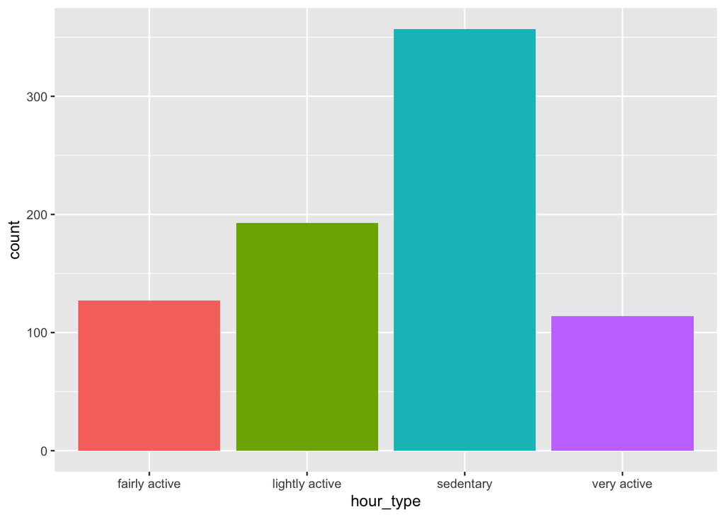

```r
step_hour_type %>%
  ggplot(aes(x=hour_type,fill=hour_type))+geom_bar()+theme(legend.position="none")
```

#### For Calories:

```r
 cal_hour_type <- hourly_average %>%
  mutate(hour_type = case_when(
    mean_Hcals < 85 ~ "sedentary",
    mean_Hcals >= 85 & mean_Hcals < 127.5 ~ "lightly active",
    mean_Hcals >= 127.5 & mean_Hcals < 170 ~ "fairly active",
    mean_Hcals >= 170~ "very active"
  )) %>%
  drop_na()

head(cal_hour_type)
```

```
## # A tibble: 6 × 5
## # Groups:   id [1]
##           id time     mean_Hcals meanH_steps hour_type
##        <dbl> <chr>         <dbl>       <dbl> <chr>
## 1 1503960366 00:00:00       61.0         3.6 sedentary
## 2 1503960366 01:00:00       53.9         2.1 sedentary
## 3 1503960366 02:00:00       50.3        15.5 sedentary
## 4 1503960366 03:00:00       48.6        39.2 sedentary
## 5 1503960366 04:00:00       47.7       188.  sedentary
## 6 1503960366 05:00:00       47.6      1085.  sedentary
```

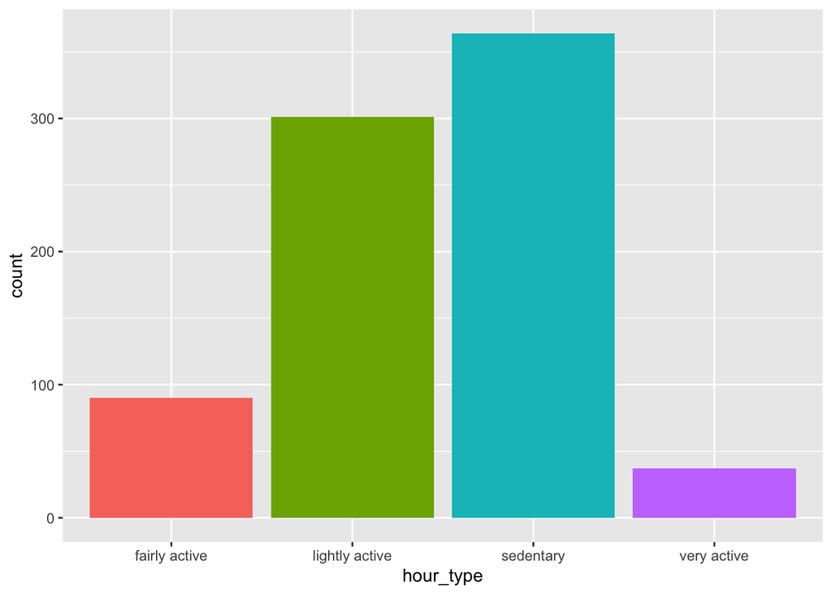

```r
cal_hour_type %>%
  ggplot(aes(x=hour_type, fill=hour_type))+geom_bar()+theme(legend.position="none")
```

###### The count of “light activity” is much more present in the calories burned graph. I believe this could be due to weight differences in the participants. Meaning someone who is 400 pounds will burn more calories from 100 steps than an individual who weighs 100 pounds.

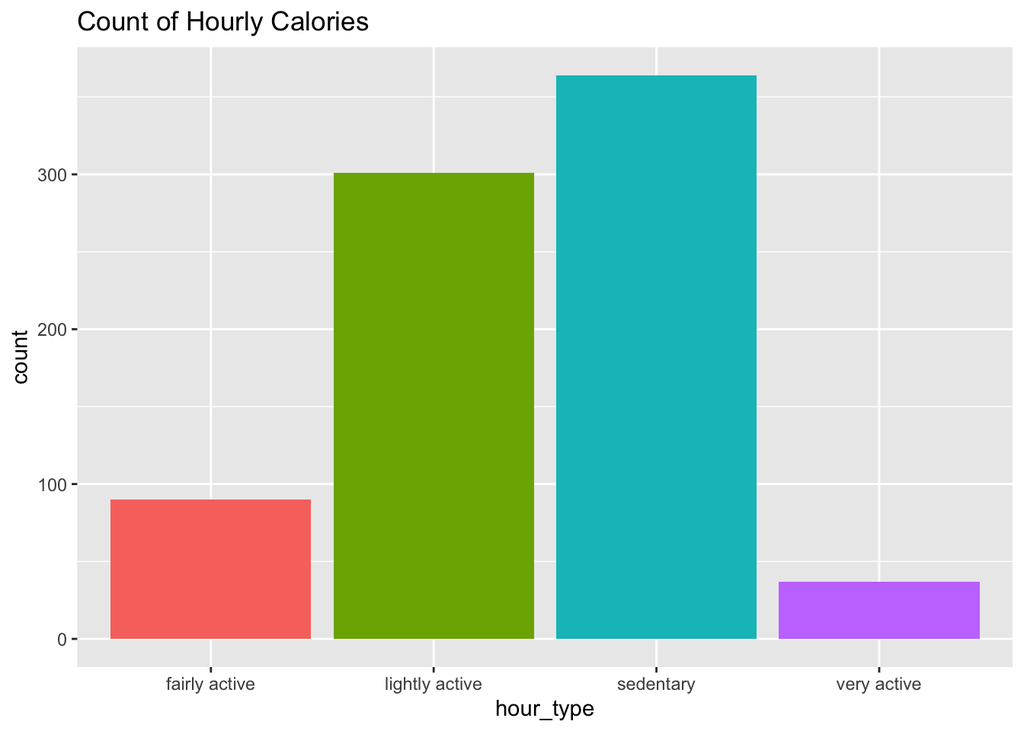

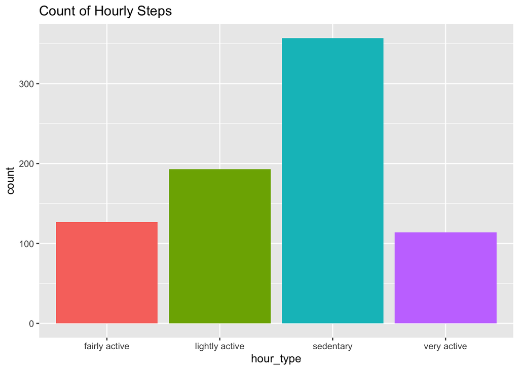

```r
cal_hour_type %>%
  ggplot(aes(x=hour_type, fill=hour_type))+geom_bar()+theme(legend.position="none")+ggtitle("Count of Hourly Calories")
step_hour_type %>%
  ggplot(aes(x=hour_type,fill=hour_type))+geom_bar()+theme(legend.position="none")+ggtitle("Count of Hourly Steps")
```

###### One of our goals should be to reduce the amount of sedentary hours for our users. Of course we should still expect to see sedentary hours as very common due to our need for rest and recovery. Yet by promoting more steps every hour with a reminder (for example) we will have healthier customers who also have higher levels of engagement with our product.

#### 5.3 Counting the sum of each Activity Type by Hour

###### To find the most active hours of the day, we will count the amount of times each type appears in the given hour.

##### Starting with Steps:

```r
countS<-step_hour_type %>%
  group_by(time) %>%
  mutate(count=str_count(hour_type,"sedentary")) %>%
  summarise(count=sum(count))

str(countS)
```

```
## tibble [24 × 2] (S3: tbl_df/tbl/data.frame)
##  $ time : chr [1:24] "00:00:00" "01:00:00" "02:00:00" "03:00:00" ...
##  $ count: int [1:24] 32 31 24 15 8 11 6 3 4 3 ...
```

```r
countL<-step_hour_type %>%
  group_by(time) %>%
  mutate(countLL=str_count(hour_type,"lightly active")) %>%
  summarise(count=sum(countLL))

str(countL)
```

```
## tibble [24 × 2] (S3: tbl_df/tbl/data.frame)
##  $ time : chr [1:24] "00:00:00" "01:00:00" "02:00:00" "03:00:00" ...
##  $ count: int [1:24] 1 1 4 9 13 7 10 10 11 9 ...
```

```r
countF<-step_hour_type %>%
  group_by(time) %>%
  mutate(countFF=str_count(hour_type,"fairly active")) %>%
  summarise(count=sum(countFF))

str(countF)
```

```
## tibble [24 × 2] (S3: tbl_df/tbl/data.frame)
##  $ time : chr [1:24] "00:00:00" "01:00:00" "02:00:00" "03:00:00" ...
##  $ count: int [1:24] 0 1 2 4 7 9 7 13 9 14 ...
```

```r
countV<-step_hour_type %>%
  group_by(time) %>%
  mutate(countVV=str_count(hour_type,"very active")) %>%
  summarise(count=sum(countVV))

str(countV)
```

```
## tibble [24 × 2] (S3: tbl_df/tbl/data.frame)
##  $ time : chr [1:24] "00:00:00" "01:00:00" "02:00:00" "03:00:00" ...
##  $ count: int [1:24] 0 0 3 5 5 6 10 6 9 7 ...
```

##### Next, Calories Burned:

```r
countSC<-cal_hour_type %>%
  group_by(time) %>%
  mutate(count=str_count(hour_type,"sedentary")) %>%
  summarise(count=sum(count))

str(countSC)
```

```
## tibble [24 × 2] (S3: tbl_df/tbl/data.frame)
##  $ time : chr [1:24] "00:00:00" "01:00:00" "02:00:00" "03:00:00" ...
##  $ count: int [1:24] 25 24 27 28 28 26 23 15 13 12 ...
```

```r
countLC<-cal_hour_type %>%
  group_by(time) %>%
  mutate(countLL=str_count(hour_type,"lightly active")) %>%
  summarise(count=sum(countLL))

str(countLC)
```

```
## tibble [24 × 2] (S3: tbl_df/tbl/data.frame)
##  $ time : chr [1:24] "00:00:00" "01:00:00" "02:00:00" "03:00:00" ...
##  $ count: int [1:24] 8 9 6 5 5 5 6 13 13 13 ...
```

```r
countFC<-cal_hour_type %>%
  group_by(time) %>%
  mutate(countFF=str_count(hour_type,"fairly active")) %>%
  summarise(count=sum(countFF))

str(countFC)
```

```
## tibble [24 × 2] (S3: tbl_df/tbl/data.frame)
##  $ time : chr [1:24] "00:00:00" "01:00:00" "02:00:00" "03:00:00" ...
##  $ count: int [1:24] 0 0 0 0 0 1 2 4 5 5 ...
```

```r
countVC<-cal_hour_type %>%
  group_by(time) %>%
  mutate(countVV=str_count(hour_type,"very active")) %>%
  summarise(count=sum(countVV))

str(countVC)
```

```
## tibble [24 × 2] (S3: tbl_df/tbl/data.frame)
##  $ time : chr [1:24] "00:00:00" "01:00:00" "02:00:00" "03:00:00" ...
##  $ count: int [1:24] 0 0 0 0 0 1 2 1 2 3 ...
```

### 5.4 Graph Discussion

###### Here is a side by side comparison of each activity type for hourly calories burned (left), & hourly steps (right):

[figure not shown]

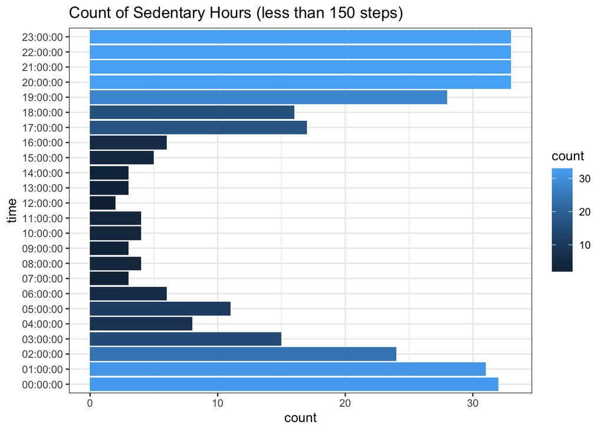

[figure not shown]

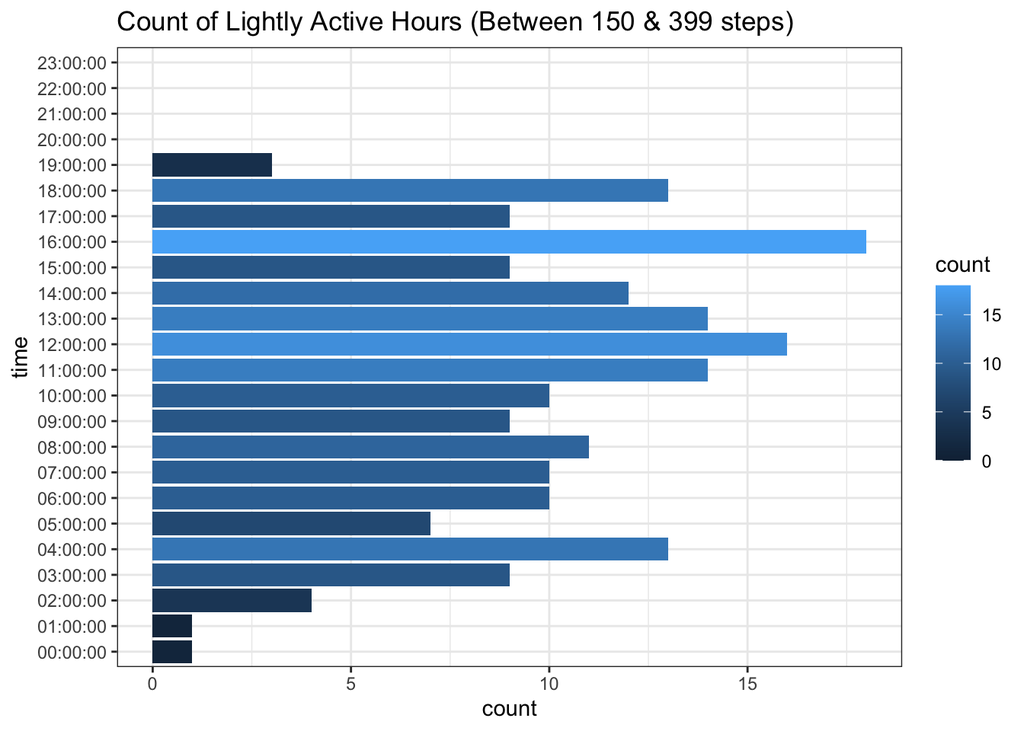

[figure not shown]

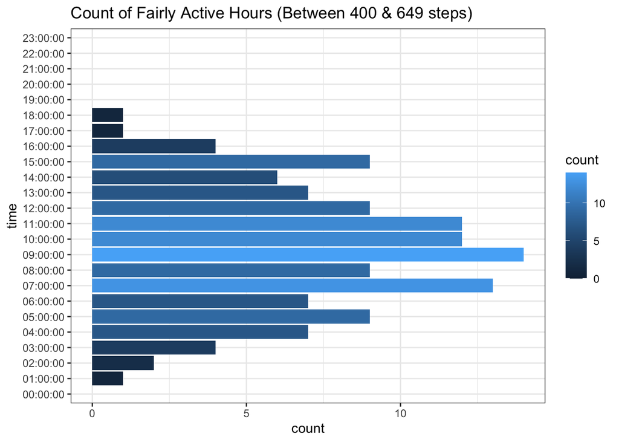

[figure not shown]

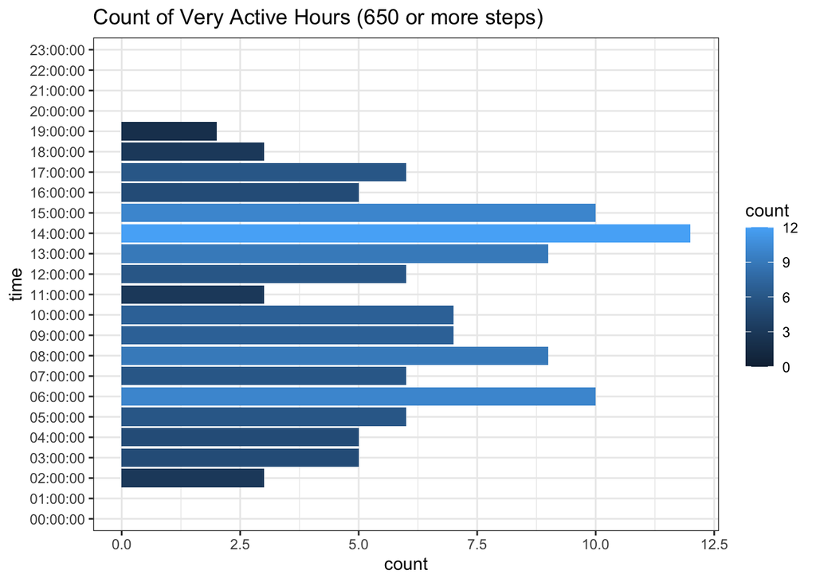

```r
countSC %>%
  ggplot(aes(x=time,y=count,fill=count))+geom_col()+ggtitle("Count of Sedentary Hours (less than 60 calories burned")+theme_bw()+coord_flip()

countS %>%
  ggplot(aes(x=time,y=count, fill=count))+geom_col()+ggtitle("Count of Sedentary Hours (less than 150 steps)")+theme_bw()+coord_flip()

countLC %>%
  ggplot(aes(x=time,y=count,fill=count))+geom_col()+ggtitle("Count of Lightly Active Hours (Between 60 & 89 calories burned in 1 hour)")+theme_bw()+coord_flip()

countL %>%
  ggplot(aes(x=time,y=count,fill=count))+geom_col()+ggtitle("Count of Lightly Active Hours (Between 150 & 399 steps)")+theme_bw()+coord_flip()

countFC %>%
  ggplot(aes(x=time,y=count,fill=count))+geom_col()+ggtitle("Count of Fairly Active Hours (Between 90 & 119 calories burned in 1 hour)")+theme_bw()+coord_flip()

countF %>%
  ggplot(aes(x=time,y=count,fill=count))+geom_col()+ggtitle("Count of Fairly Active Hours (Between 400 & 649 steps)")+theme_bw()+coord_flip()

countVC %>%
  ggplot(aes(x=time,y=count,fill=count))+geom_col()+ggtitle("Count of Very Active Hours (120 or more calories burned)")+theme_bw()+coord_flip()

countV %>%
  ggplot(aes(x=time,y=count,fill=count))+geom_col()+ggtitle("Count of Very Active Hours (650 or more steps)")+theme_bw()+coord_flip()
```

##### These charts produce some interesting results,

###### You can see the sedentary hours are most common overnight, this is (of course) due to the lack of movement during sleep. As day arrives, the count of increased activity types rises as well.

###### When looking at the other 3 types, you can see there is an odd amount of activity during the hours of 2-3am. This could either be individuals that like to have a night out, or a watch malfunction. Either way, unless malfunctions are very common, I believe it is largely due to sampling bias.

###### The time with the most activity appears to be slightly different depending between the two types. Exercises involving less steps and seem to peak slightly later in the day (around 13-19:00). It’s important to note here that calories is a better indicator when tracking exercise types that require less movement. Exercises that do require movement will be shown by both increased steps & calories, and these appear to peak between 9-15:00 according to the activity graphs.

###### Much of this data will help the company build a complete profile of each user. Building this profile not only helps us correctly market to these individuals, but also helps the customers fulfill their fitness goals. For example, by sending a notification at their usual time of exercise reminding them to workout, we could see increased consistency in their routine.

##### To demonstrate how Steps & Calories burned per hour are indeed correlated, Here is data taken from dailyActivity showing Total Daily Steps vs. Total Daily Calories Burned:

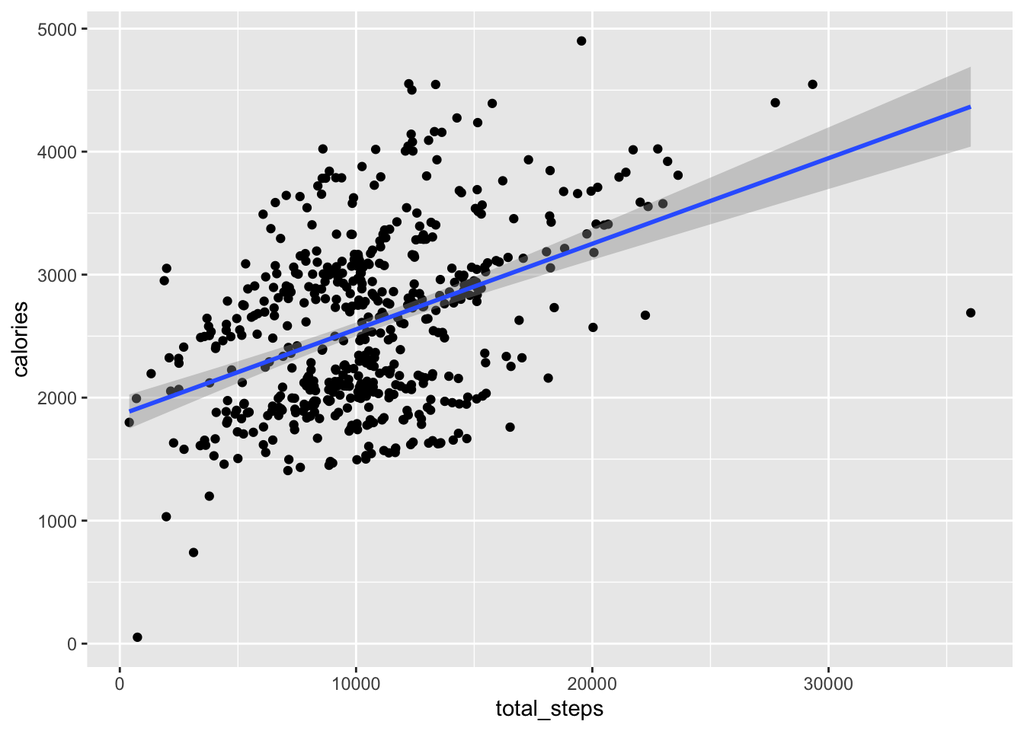

```r
dailyActivity %>%
  ggplot(aes(x=total_steps, y=calories))+geom_point()+geom_smooth(method = "lm")
```

##### Yet when we look at this on the hourly distribution:

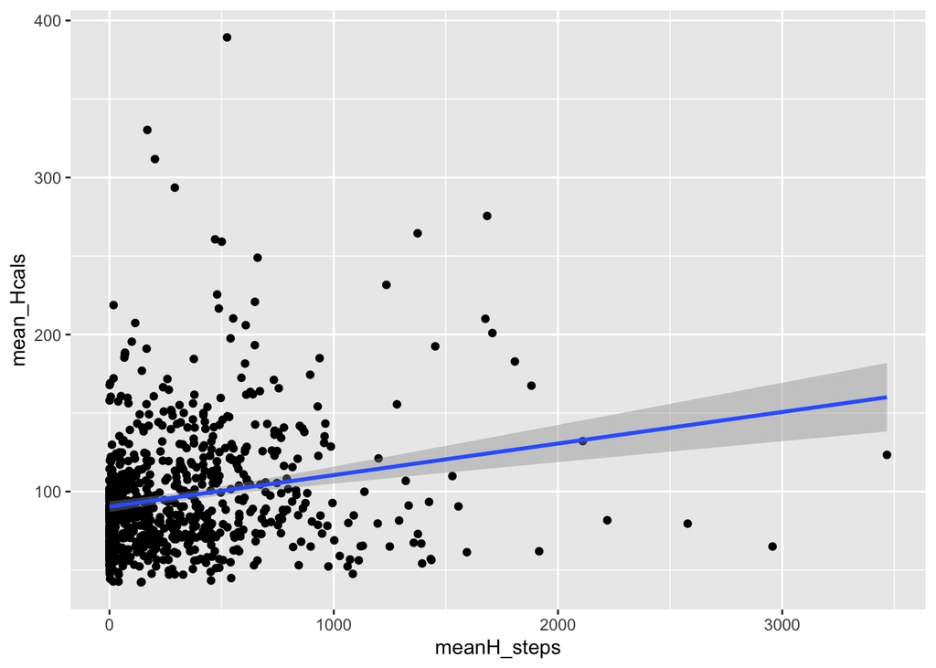

```r
hourly_average %>%
  ggplot(aes(x=meanH_steps, y=mean_Hcals))+geom_point()+geom_smooth(method="lm")
```

###### This graph is much less clear than the former. You can see a large majority of the data is closer to the origin, which displays the frequency of low activity compared to high activity hours.

###### One of the most confusing things about this graph is that many of datapoints with the highest hourly step count average have very low calories being burned. This gives further evidence that there is a watch malfunction (as one cannot move without burning more calories).

On the other hand, calories can be burned without steps being taken, so we will treat this data as legitimate.

### 5.5 Stationary vs. Mobile Exercise

###### So how can we distinguish between an individual going for a run and a watch malfunction? One way is to find those that are both “Very Active” (in terms of mean hourly steps) and “Sedentary” (in terms of mean hourly calories burned). These are individuals that are taking a high amount of steps without burning virtually any calories, which is impossible. These results are likely due to a watch malfunction and should be treated as such.

###### Secondly, if an individual is “Very Active” in both categories, “Very Active” or “Faily Active” for both, or “Fairly Active” in Both, it is likely that they are exercising in a way that requires movement.

###### a similar method is used for the next category: those burning calories but not taking many steps are likely engaging in stationary exercise (weightlifting, yoga, etc..). By grouping those who are either “Sedentary”, “Lightly Active” (in terms of steps taken), with the “Very Active” calories burned type we will find those who are exercising without much movement. With steps taken, I am not considering Light Activity to be “mobile exercise”. The range of Light Exercise is low enough that simply walking to and from different equipment in a gym might be included in it. This should of course be a case by case depending on an individuals weight, age, and health. But due to limitations of this data this cannot be done.

###### This also presents another shortcoming of this product that should be highlighted. By allowing a customer to categorize their own workout, it will take much responsibility off this data to correctly group each individual based off steps and calories burned.

###### While you most definitely can categorize individuals from data collected, it would never be more accurate than simply asking the customer to declare what type of exercise they partook in. Having these user-created labels included in future data sets would also allow our models to have higher levels of accuracy. Being able to identify what type of exercise an individual is doing is vital because being able to categorize our customers means our marketing can be more tailored to each user.

##### Quantifying Stationary Exercise, Mobile Exercise, and Watch Malfunction:

```r
stationary <- hourly_average %>%
  mutate(hour_type = case_when(
    meanH_steps < 400 & mean_Hcals >=170 ~ "Stationary Exercise",
    meanH_steps < 400 & mean_Hcals >=127.5 & mean_Hcals < 170 ~ "Fairly Active Stationary Exercise"

  )) %>%
  group_by(id) %>%
  drop_na()
head(stationary)
```

```
## # A tibble: 6 × 5
## # Groups:   id [2]
##           id time     mean_Hcals meanH_steps hour_type
##        <dbl> <chr>         <dbl>       <dbl> <chr>
## 1 1644430081 12:00:00       130.       327   Fairly Active Stationary Exercise
## 2 1644430081 19:00:00       195.        99.5 Stationary Exercise
## 3 1644430081 20:00:00       160.        80.7 Fairly Active Stationary Exercise
## 4 1644430081 21:00:00       157.        39.0 Fairly Active Stationary Exercise
## 5 1644430081 22:00:00       135.        44.2 Fairly Active Stationary Exercise
## 6 2022484408 16:00:00       143.       124.  Fairly Active Stationary Exercise
```

```r
running <- hourly_average %>%
  mutate(hour_type = case_when(
    meanH_steps >= 650 & mean_Hcals >=170 ~ "Mobile Exercise",
    meanH_steps>= 400 & meanH_steps<650 & mean_Hcals>=127.5 ~ "Fairly Active Mobile Exercise"
  )) %>%
  group_by(id) %>%
  drop_na()
head(running)
```

```
## # A tibble: 6 × 5
## # Groups:   id [2]
##           id time     mean_Hcals meanH_steps hour_type
##        <dbl> <chr>         <dbl>       <dbl> <chr>
## 1 1644430081 13:00:00       140.        428. Fairly Active Mobile Exercise
## 2 1644430081 18:00:00       160.        496  Fairly Active Mobile Exercise
## 3 2022484408 09:00:00       221.        649. Fairly Active Mobile Exercise
## 4 2022484408 10:00:00       201.       1708. Mobile Exercise
## 5 2022484408 14:00:00       193.        648. Fairly Active Mobile Exercise
## 6 2022484408 15:00:00       128.        415. Fairly Active Mobile Exercise
```

```r
malfunction <- hourly_average %>%
  mutate(hour_type = case_when(
    meanH_steps >= 650 & mean_Hcals < 85 ~ "Malfunction"
  )) %>%
  group_by(id) %>%
  drop_na()
head(malfunction)
```

```
## # A tibble: 6 × 5
## # Groups:   id [3]
##           id time     mean_Hcals meanH_steps hour_type
##        <dbl> <chr>         <dbl>       <dbl> <chr>
## 1 1503960366 05:00:00       47.6       1085. Malfunction
## 2 1503960366 10:00:00       80.6        720. Malfunction
## 3 1503960366 15:00:00       78.2        972. Malfunction
## 4 1503960366 16:00:00       84.8       1089. Malfunction
## 5 1624580081 06:00:00       56.1        660. Malfunction
## 6 2022484408 05:00:00       62         1916. Malfunction
```

##### Merging Stationary, Mobile Exercise, & Malfunction:

```r
gymRunM<-rbind(stationary,running,malfunction)
gymRun<-rbind(stationary,running)
```

### 5.6 Stationary vs. Mobile Exercise Graph

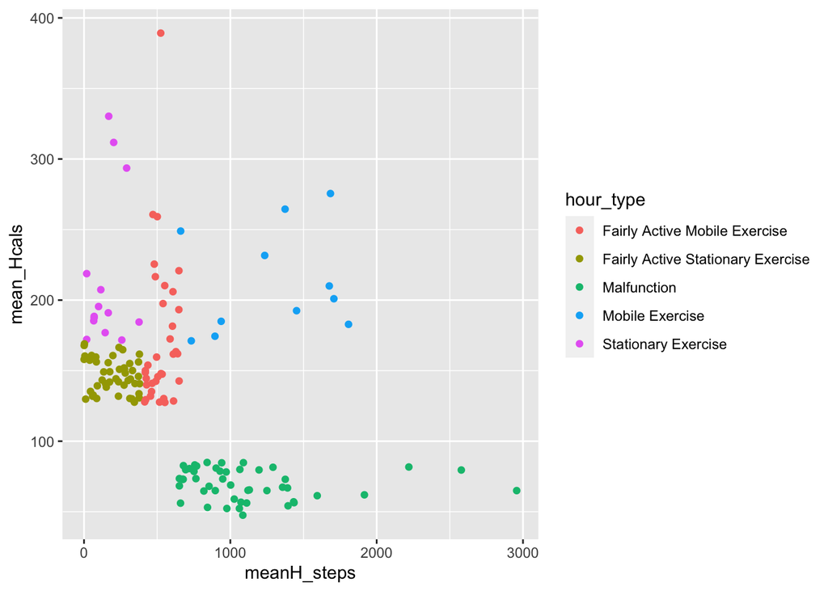

```r
gymRunM %>%
  ggplot(aes(x=meanH_steps, y=mean_Hcals, color=hour_type))+geom_point()
```

###### You can see here the Malfunction types have a relatively significant impact on the structure of the plot. When we remove them it looks like this:

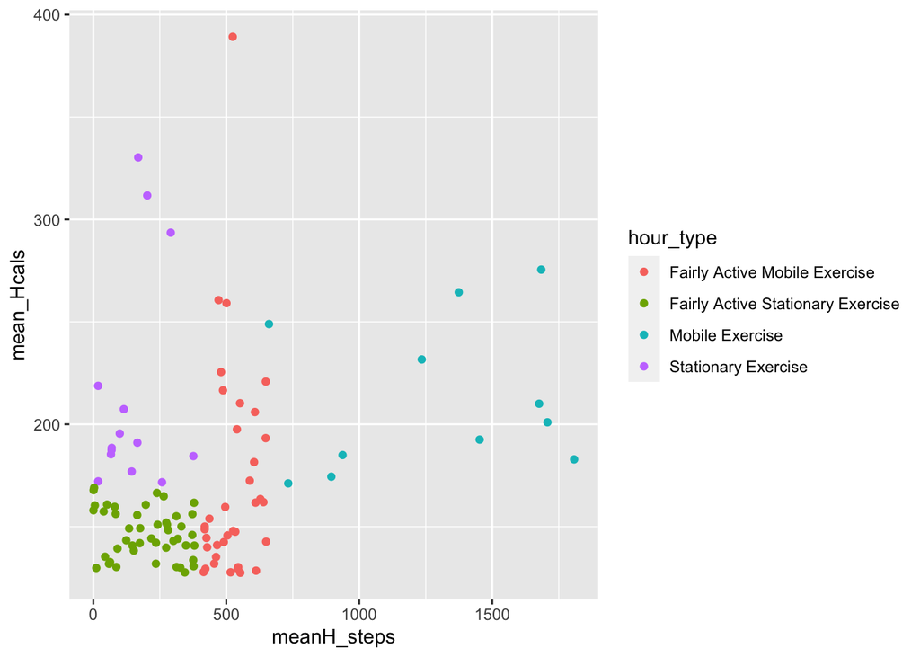

```r
gymRun %>%
  ggplot(aes(x=meanH_steps, y=mean_Hcals, color=hour_type))+geom_point()
```

###### These are the hours where we can confidently say an individual is engaged in either stationary or mobile exercise. Unfortunately, this likely does not include every single case of exercise in the data set, but saying anyone is exercising when their calories burned or steps are “Light Activity” type would be an assumption. By allowing the user to label their own exercise, we would be able to include the missing data in this graph.

### 5.7 Impact of Malfunctions

###### In order to demonstrate how malfunctions impact our data, I will remove them from hourly_averages and compare the new graph (without malfunctions) to the former.

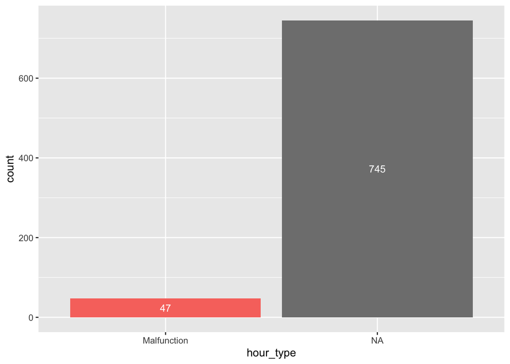

```r
hourly_average2 <- hourly_average %>%
   mutate(hour_type = case_when(
    meanH_steps >= 650 & mean_Hcals < 85 ~ "Malfunction"
  ))



hourly_average2 %>%
  ggplot(aes(x=hour_type, fill=hour_type))+geom_bar()+stat_count(geom = "text", colour = "white", size = 3.5,
aes(label = ..count..),position=position_stack(vjust=0.5))+theme(legend.position="none")
```

```r
hourly_average2<-filter(hourly_average2, is.na(hour_type))


nrow(hourly_average2)
```

```
## [1] 745
```

```r
nrow(hourly_average)
```

```
## [1] 792
```

##### Before & After (Hourly_Average):

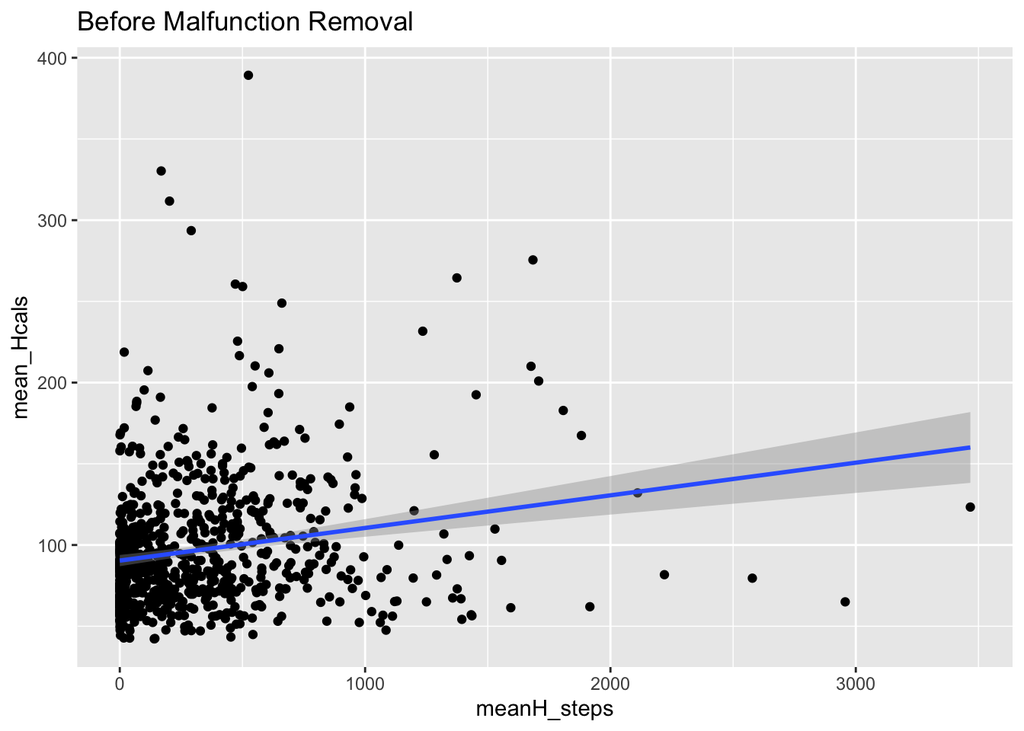

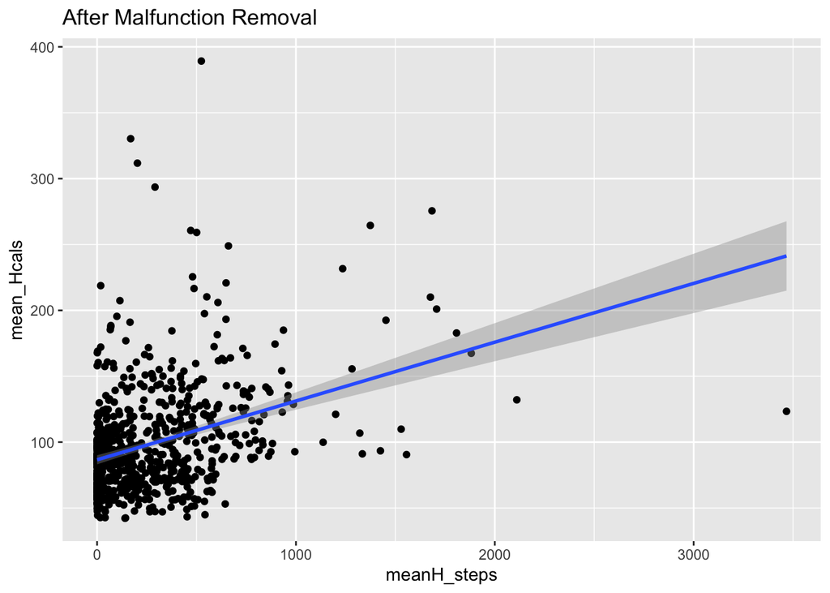

```r
hourly_average %>%
  ggplot(aes(x=meanH_steps, y=mean_Hcals))+geom_point()+geom_smooth(method = "lm")+ggtitle("Before Malfunction Removal")
hourly_average2 %>%
  ggplot(aes(x=meanH_steps, y=mean_Hcals))+geom_point()+geom_smooth(method="lm")+ggtitle("After Malfunction Removal")
```

###### By looking at the trend line you can see the impact of removing these malfunctions from our data set. We should streamline a method to detect these malfunctions either in the watch or during our analysis process. We should also be thinking about potentially prioritizing a watch design that doesn’t malfunction as much.

### 6. Conclusion

##### How to identify certain activity types & the importance of self-identification:

###### During the case study I grouped individuals into either stationary or mobile exercise based on the data provided. By grouping these individuals we can will improve the accuracy of our marketing strategies. For example, we would be able to more accurately predict if an individual would be more interested in running or gym equipment based off their exercise preference.

###### To take this a step further, we should be directly asking and keeping track of what type of exercises our customers are partaking in. This would not only be more accurate and display a more complete picture, but also take a lot of pressure off our analysts to provide accurate findings.

##### Daily exercise times and notifications:

###### By looking at the distribution of the available hourly data, we can find each user’s usual time of exercise. By tracking a user’s daily exercise routine, our watch could send notifications around the time of usual activity to increase consistency and engagement.

##### Increased engagement with reduction of sedentary hours:

###### As these devices are marketed as smart fitness devices, most users will likely be interested in self improvement and increased activity. By notifying individuals with the intent to help reduce the count of sedentary hours we would be helping them with this goal, and (again) increasing engagement with our product. An example of this would be reminding users to stand and move once an hour.

##### Note:

###### Privacy concerns: In future cases, these individuals would need to be prompted and made aware of how their data is being used. The transparency of our process would be essential in gaining the trust of our users. These processes would improve the customer experience, so we should give the customer every guarantee that their data is being used for their own benefit.

###### Data Limitations: Again, this data was collected by 33 users over 31 days. More research is required to make any concrete conclusions. This is a great start and should be the first step in a larger scale project.